# [빅데이터처리]32151671-박민혁[기말고사 대체과제]

## 2021년 1학기 빅데이터 기말고사 대체 과제

이름 : 박민혁

학번 : 32151671

### 데이터 설명

2017년 01월 01일 01시 ~ 2017년 03월 31일 24시까지 측정한 대전광역시 내 지역별 미세먼지 측정 데이터셋이다.

```python
# 분석에 필요한 패키지 불러오기
import os
import pandas as pd
import numpy as np
import statsmodels.api as sm
import matplotlib.pyplot as plt
import seaborn as sns
```

```python
# 데이터 불러오기
data = pd.read_csv('Final.csv', engine = 'python', encoding='CP949') # CP949는 한글 깨짐 현상 방지
data.head()
```

|  | location | zipcode | zip_location | date | time | SO2 | CO | O3 | NO2 | PM10 | PM25 | address |
| --- | --- | --- | --- | --- | --- | --- | --- | --- | --- | --- | --- | --- |
| 0 | 대전 대덕구 | 525111 | 읍내동 | 20170101 | 1 | 0.004 | 1.1 | 0.002 | 0.036 | 40.0 | 34.0 | 대전 대덕구 대전로 1331번길 75(태아산업(주)) |
| 1 | 대전 대덕구 | 525111 | 읍내동 | 20170101 | 2 | 0.004 | 1.2 | 0.002 | 0.034 | 40.0 | 38.0 | 대전 대덕구 대전로 1331번길 75(태아산업(주)) |
| 2 | 대전 대덕구 | 525111 | 읍내동 | 20170101 | 3 | 0.004 | 1.1 | 0.002 | 0.030 | 37.0 | NaN | 대전 대덕구 대전로 1331번길 75(태아산업(주)) |
| 3 | 대전 대덕구 | 525111 | 읍내동 | 20170101 | 4 | 0.003 | 1.3 | 0.002 | 0.028 | 36.0 | NaN | 대전 대덕구 대전로 1331번길 75(태아산업(주)) |
| 4 | 대전 대덕구 | 525111 | 읍내동 | 20170101 | 5 | 0.003 | 1.5 | 0.002 | 0.026 | 37.0 | NaN | 대전 대덕구 대전로 1331번길 75(태아산업(주)) |

```python
data.shape
```

```
(21600, 12)
```

```python
data.tail()
```

|  | location | zipcode | zip_location | date | time | SO2 | CO | O3 | NO2 | PM10 | PM25 | address |
| --- | --- | --- | --- | --- | --- | --- | --- | --- | --- | --- | --- | --- |
| 21595 | 대전 서구 | 525173 | 월평동 | 20170331 | 20 | 0.001 | 0.3 | 0.041 | 0.026 | 28.0 | 25.0 | 대전 서구 월평동160-5 |
| 21596 | 대전 서구 | 525173 | 월평동 | 20170331 | 21 | 0.001 | 0.3 | 0.037 | 0.021 | 22.0 | 19.0 | 대전 서구 월평동160-5 |
| 21597 | 대전 서구 | 525173 | 월평동 | 20170331 | 22 | 0.001 | 0.3 | 0.028 | 0.025 | 23.0 | 18.0 | 대전 서구 월평동160-5 |
| 21598 | 대전 서구 | 525173 | 월평동 | 20170331 | 23 | 0.001 | 0.2 | 0.033 | 0.021 | 21.0 | 14.0 | 대전 서구 월평동160-5 |
| 21599 | 대전 서구 | 525173 | 월평동 | 20170331 | 24 | 0.001 | 0.2 | 0.037 | 0.016 | 16.0 | 14.0 | 대전 서구 월평동160-5 |

```python
data.info()
```

```
<class 'pandas.core.frame.DataFrame'>
RangeIndex: 21600 entries, 0 to 21599
Data columns (total 12 columns):
 #   Column        Non-Null Count  Dtype
---  ------        --------------  -----
 0   location      21600 non-null  object
 1   zipcode       21600 non-null  int64
 2   zip_location  21600 non-null  object
 3   date          21600 non-null  int64
 4   time          21600 non-null  int64
 5   SO2           21484 non-null  float64
 6   CO            21473 non-null  float64
 7   O3            21483 non-null  float64
 8   NO2           21498 non-null  float64
 9   PM10          21105 non-null  float64
 10  PM25          16978 non-null  float64
 11  address       21600 non-null  object
dtypes: float64(6), int64(3), object(3)
memory usage: 2.0+ MB
```

location : 대전광역시 내 지역

zipcode : 측정한 지역 코드

zip_location : 측정한 지역

date : 측정 날짜

time : 측정 시간

SO2 : 이산화 황 농도

CO : 일산화탄소 농도

O3 : 오존 농도

NO2 : 이산화질소 농도

PM10 : 미세먼지 농도

PM25 : 초미세먼지 농도

address : 주소

```python
data.info()
```

```
<class 'pandas.core.frame.DataFrame'>
RangeIndex: 21600 entries, 0 to 21599
Data columns (total 12 columns):
 #   Column        Non-Null Count  Dtype
---  ------        --------------  -----
 0   location      21600 non-null  object
 1   zipcode       21600 non-null  int64
 2   zip_location  21600 non-null  object
 3   date          21600 non-null  int64
 4   time          21600 non-null  int64
 5   SO2           21484 non-null  float64
 6   CO            21473 non-null  float64
 7   O3            21483 non-null  float64
 8   NO2           21498 non-null  float64
 9   PM10          21105 non-null  float64
 10  PM25          16978 non-null  float64
 11  address       21600 non-null  object
dtypes: float64(6), int64(3), object(3)
memory usage: 2.0+ MB
```

```python
data.describe()
```

|  | zipcode | date | time | SO2 | CO | O3 | NO2 | PM10 | PM25 |
| --- | --- | --- | --- | --- | --- | --- | --- | --- | --- |
| count | 21600.000000 | 2.160000e+04 | 21600.000000 | 21484.000000 | 21473.000000 | 21483.000000 | 21498.000000 | 21105.000000 | 16978.000000 |
| mean | 525145.500000 | 2.017022e+07 | 12.500000 | 0.004204 | 0.533652 | 0.023994 | 0.024309 | 50.419995 | 26.639828 |
| std | 23.075412 | 8.345720e+01 | 6.922347 | 0.002326 | 0.275504 | 0.017818 | 0.013997 | 22.910648 | 16.965332 |
| min | 525111.000000 | 2.017010e+07 | 1.000000 | 0.001000 | 0.100000 | 0.001000 | 0.002000 | 4.000000 | 1.000000 |
| 25% | 525121.000000 | 2.017012e+07 | 6.750000 | 0.003000 | 0.300000 | 0.007000 | 0.013000 | 34.000000 | 14.000000 |
| 50% | 525146.500000 | 2.017021e+07 | 12.500000 | 0.004000 | 0.500000 | 0.023000 | 0.021000 | 46.000000 | 23.000000 |
| 75% | 525171.000000 | 2.017031e+07 | 18.250000 | 0.005000 | 0.700000 | 0.036000 | 0.034000 | 62.000000 | 35.000000 |
| max | 525173.000000 | 2.017033e+07 | 24.000000 | 0.034000 | 2.400000 | 0.111000 | 0.085000 | 191.000000 | 135.000000 |

```python
data.isna().sum()
```

```
location           0
zipcode            0
zip_location       0
date               0
time               0
SO2              116
CO               127
O3               117
NO2              102
PM10             495
PM25            4622
address            0
dtype: int64
```

## 상관계수

상관계수란 X와 Y사이의 선형성의 정도를 나타내는 측도이다. 다시 말해 X와 Y의 상관관계를 나타내는 수치이다. 상관계수는 -1부터 1사이의 숫자로 표시되는데 절댓값으로 1에 가까울수록 상관관계가 강한 것이다. 상관계수가 0이면 두 변수간의 상관관계가 없다는 뜻이고 0에 가까울수록 관련성이 적다. 상관계수가 양의 값을 가질 경우 X가 증가할 때 Y 또한 증가한다는 경향이 있음을 의미한다. 음의 값을 가질 때는 X가 증가할 때 Y는 감소하는 경향이 있음을 의미한다.

```python
data.corr()
```

|  | zipcode | date | time | SO2 | CO | O3 | NO2 | PM10 | PM25 |
| --- | --- | --- | --- | --- | --- | --- | --- | --- | --- |
| zipcode | 1.000000 | 0.000000 | 0.000000 | -0.264978 | -0.071816 | -0.021873 | -0.052825 | -0.150545 | -0.126954 |
| date | 0.000000 | 1.000000 | 0.000000 | 0.032226 | -0.179547 | 0.392798 | -0.103057 | 0.070137 | 0.090024 |
| time | 0.000000 | 0.000000 | 1.000000 | 0.052406 | -0.163685 | 0.222876 | 0.053354 | -0.016184 | -0.111049 |
| SO2 | -0.264978 | 0.032226 | 0.052406 | 1.000000 | 0.445054 | -0.133858 | 0.434545 | 0.370809 | 0.307125 |
| CO | -0.071816 | -0.179547 | -0.163685 | 0.445054 | 1.000000 | -0.571427 | 0.682065 | 0.480127 | 0.563456 |
| O3 | -0.021873 | 0.392798 | 0.222876 | -0.133858 | -0.571427 | 1.000000 | -0.679562 | -0.135975 | -0.221516 |
| NO2 | -0.052825 | -0.103057 | 0.053354 | 0.434545 | 0.682065 | -0.679562 | 1.000000 | 0.422122 | 0.441158 |
| PM10 | -0.150545 | 0.070137 | -0.016184 | 0.370809 | 0.480127 | -0.135975 | 0.422122 | 1.000000 | 0.820150 |
| PM25 | -0.126954 | 0.090024 | -0.111049 | 0.307125 | 0.563456 | -0.221516 | 0.441158 | 0.820150 | 1.000000 |

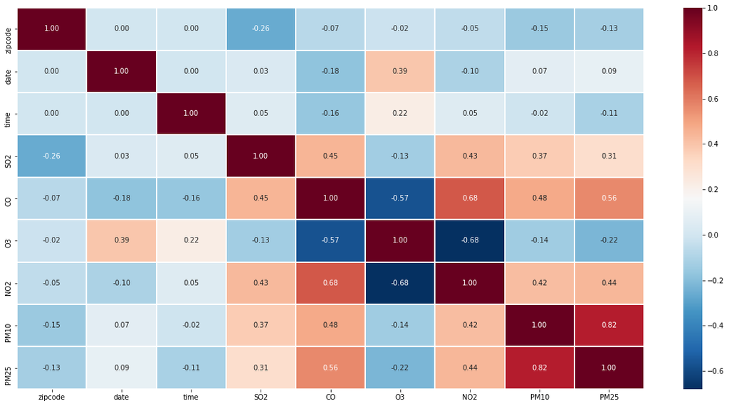

```python
f, ax = plt.subplots(figsize = (20, 10))
sns.heatmap(data.corr(), annot= True, fmt='0.2f', linewidths = 2, cmap = 'RdBu_r')
```

## SO2/CO/NO2/O3로 각각 단순 선형 회귀 분석

```python
time_data = data.groupby(['time'], as_index = False).agg({'SO2':'mean', 'NO2':'mean', 'O3':'mean', 'CO':'mean', 'PM10':'mean', 'PM25':'mean'})
```

### target ~ SO2/CO/NO2/O3 (시간)

```python
target = time_data.dropna()[['PM10']]
SO2 = time_data.dropna()[['SO2']]
CO = time_data.dropna()[['CO']]
NO2 = time_data.dropna()[['NO2']]
O3 = time_data.dropna()[['O3']]
```

```python
SO2_1 = sm.add_constant(SO2, has_constant = 'add')
CO_1 = sm.add_constant(CO, has_constant = 'add')
NO2_1 = sm.add_constant(NO2, has_constant = 'add')
O3_1 = sm.add_constant(O3, has_constant = 'add')

model1, model2, model3, model4 = sm.OLS(target, SO2_1), sm.OLS(target,CO_1), sm.OLS(target,NO2_1), sm.OLS(target, O3_1)
fitted_model1, fitted_model2, fitted_model3, fitted_model4 = model1.fit(), model2.fit(), model3.fit(), model4.fit()

fitted_model1.summary()
```

OLS Regression Results

| Dep. Variable: | PM10 | R-squared: | 0.749 |
| --- | --- | --- | --- |
| Model: | OLS | Adj. R-squared: | 0.737 |
| Method: | Least Squares | F-statistic: | 65.55 |
| Date: | Fri, 18 Jun 2021 | Prob (F-statistic): | 4.83e-08 |
| Time: | 13:03:54 | Log-Likelihood: | -51.208 |
| No. Observations: | 24 | AIC: | 106.4 |
| Df Residuals: | 22 | BIC: | 108.8 |
| Df Model: | 1 |  |  |
| Covariance Type: | nonrobust |  |  |

|  | coef | std err | t | P>\|t\| | [0.025 | 0.975] |
| --- | --- | --- | --- | --- | --- | --- |
| const | 8.4195 | 5.205 | 1.617 | 0.120 | -2.376 | 19.215 |
| SO2 | 9989.8249 | 1233.836 | 8.097 | 0.000 | 7431.006 | 1.25e+04 |

| Omnibus: | 4.110 | Durbin-Watson: | 0.280 |
| --- | --- | --- | --- |
| Prob(Omnibus): | 0.128 | Jarque-Bera (JB): | 1.493 |
| Skew: | -0.001 | Prob(JB): | 0.474 |
| Kurtosis: | 1.778 | Cond. No. | 2.83e+03 |

Notes:  
[1] Standard Errors assume that the covariance matrix of the errors is correctly specified.  
[2] The condition number is large, 2.83e+03. This might indicate that there are  
strong multicollinearity or other numerical problems.

```python
fitted_model2.summary()
```

OLS Regression Results

| Dep. Variable: | PM10 | R-squared: | 0.294 |
| --- | --- | --- | --- |
| Model: | OLS | Adj. R-squared: | 0.262 |
| Method: | Least Squares | F-statistic: | 9.170 |
| Date: | Fri, 18 Jun 2021 | Prob (F-statistic): | 0.00618 |
| Time: | 13:03:54 | Log-Likelihood: | -63.602 |
| No. Observations: | 24 | AIC: | 131.2 |
| Df Residuals: | 22 | BIC: | 133.6 |
| Df Model: | 1 |  |  |
| Covariance Type: | nonrobust |  |  |

|  | coef | std err | t | P>\|t\| | [0.025 | 0.975] |
| --- | --- | --- | --- | --- | --- | --- |
| const | 38.5549 | 3.985 | 9.676 | 0.000 | 30.291 | 46.819 |
| CO | 22.2411 | 7.345 | 3.028 | 0.006 | 7.009 | 37.473 |

| Omnibus: | 4.516 | Durbin-Watson: | 0.226 |
| --- | --- | --- | --- |
| Prob(Omnibus): | 0.105 | Jarque-Bera (JB): | 3.359 |
| Skew: | 0.916 | Prob(JB): | 0.187 |
| Kurtosis: | 3.053 | Cond. No. | 12.9 |

Notes:  
[1] Standard Errors assume that the covariance matrix of the errors is correctly specified.

```python
fitted_model3.summary()
```

OLS Regression Results

| Dep. Variable: | PM10 | R-squared: | 0.218 |
| --- | --- | --- | --- |
| Model: | OLS | Adj. R-squared: | 0.182 |
| Method: | Least Squares | F-statistic: | 6.120 |
| Date: | Fri, 18 Jun 2021 | Prob (F-statistic): | 0.0216 |
| Time: | 13:03:55 | Log-Likelihood: | -64.837 |
| No. Observations: | 24 | AIC: | 133.7 |
| Df Residuals: | 22 | BIC: | 136.0 |
| Df Model: | 1 |  |  |
| Covariance Type: | nonrobust |  |  |

|  | coef | std err | t | P>\|t\| | [0.025 | 0.975] |
| --- | --- | --- | --- | --- | --- | --- |
| const | 40.1018 | 4.240 | 9.458 | 0.000 | 31.309 | 48.895 |
| NO2 | 424.5647 | 171.621 | 2.474 | 0.022 | 68.644 | 780.485 |

| Omnibus: | 6.201 | Durbin-Watson: | 0.244 |
| --- | --- | --- | --- |
| Prob(Omnibus): | 0.045 | Jarque-Bera (JB): | 5.067 |
| Skew: | 1.125 | Prob(JB): | 0.0794 |
| Kurtosis: | 3.040 | Cond. No. | 223. |

Notes:  
[1] Standard Errors assume that the covariance matrix of the errors is correctly specified.

```python
fitted_model4.summary()
```

OLS Regression Results

| Dep. Variable: | PM10 | R-squared: | 0.117 |
| --- | --- | --- | --- |
| Model: | OLS | Adj. R-squared: | 0.076 |
| Method: | Least Squares | F-statistic: | 2.904 |
| Date: | Fri, 18 Jun 2021 | Prob (F-statistic): | 0.102 |
| Time: | 13:03:55 | Log-Likelihood: | -66.294 |
| No. Observations: | 24 | AIC: | 136.6 |
| Df Residuals: | 22 | BIC: | 138.9 |
| Df Model: | 1 |  |  |
| Covariance Type: | nonrobust |  |  |

|  | coef | std err | t | P>\|t\| | [0.025 | 0.975] |
| --- | --- | --- | --- | --- | --- | --- |
| const | 54.0923 | 2.306 | 23.453 | 0.000 | 49.309 | 58.875 |
| O3 | -152.9946 | 89.774 | -1.704 | 0.102 | -339.174 | 33.185 |

| Omnibus: | 5.462 | Durbin-Watson: | 0.253 |
| --- | --- | --- | --- |
| Prob(Omnibus): | 0.065 | Jarque-Bera (JB): | 4.235 |
| Skew: | 1.028 | Prob(JB): | 0.120 |
| Kurtosis: | 3.085 | Cond. No. | 110. |

Notes:  
[1] Standard Errors assume that the covariance matrix of the errors is correctly specified.

위에 summary는 모형이 데이터에 잘 맞는 정도를 보여주는 지표들이다. `R-squared`

- R제곱
- 모형 적합도(혹은 설명력)
- `PM10`의 분산을 각각의 종류(SO2, CO, O3, NO2) 퍼센테이지별로 설명한다.
- 각각의 종류마다 `PM10`에 차이가 있다.

`Adj. R-squared`

- 독립변수가 여러 개인 다중회귀분석에서 사용한다.
- 독립변수의 개수와 표본의 크기를 고려하여 R-squared를 보정
- 서로 다른 모형을 비교할 대는 이 지표가 높은 쪽을 선택한다.

`F-statistic`, `Prob(F-statistic)`

`Log-Likelihood`

- 종속변수가 정규분포라 가정했을 때 그 우도
- 로그우도도 R제곱과 마찬가지로 독립변수가 많아지면 증가한다.
- `AIC`, `BIC` 로그우도를 독립변수의 수로 보정한 값(작을수록 좋은 것)

회귀계수(Coefficients)

[figure not shown]

### y_hat = beta() + beta * x 계산

```python
# np.dot -> numpy.dot은 numpy array를 곱할 때 사용한다. 두 배열의 내적곱
print('SO2 : ', (np.dot(SO2_1, fitted_model1.params)))
print('CO : ', (np.dot(CO_1, fitted_model2.params)))
print('NO2 : ', (np.dot(NO2_1, fitted_model3.params)))
print('O3 : ', (np.dot(O3_1, fitted_model4.params)))
```

```
SO2 :  [48.69025374 47.76691802 46.23173334 45.33403725 46.35635527 47.0008601
 47.9565052  49.5913404  53.12309857 56.93667973 57.91961104 56.68315778
 53.20531162 51.08269469 48.69482925 47.35848184 46.83927766 47.99756155
 49.24455182 52.25259911 52.91757387 53.62370289 52.53933996 50.65070042]
CO :  [51.67172492 51.64448079 51.54541121 51.22591181 51.43148119 51.47110902
 52.26366567 53.5193726  54.53575352 53.6374842  51.94701271 49.87449857
 48.41097769 47.52188756 46.9632638  46.604199   46.68494379 47.38645965
 48.77494251 49.63836311 50.01230945 50.5670991  51.1813305  51.48349272]
NO2 :  [50.7627011  49.92868405 49.28168328 48.82736595 49.01202092 49.71852687
 51.66472408 53.35259324 53.50898664 52.57823156 51.36088562 49.65572112
 48.28053695 47.65994541 47.19531821 47.24128253 48.10313074 49.76305622
 51.68112421 52.24626705 51.78278991 52.08739976 52.51952071 51.78467896]
O3 :  [51.10159815 51.03907139 51.09529436 51.14453206 51.35937199 51.71119153
 52.27069534 52.60172942 52.41689182 51.70220724 50.76077979 49.69312471
 48.81658301 48.32940602 48.01345909 47.95999897 48.2028003  48.84950881
 49.69763354 50.14131802 50.31085031 50.63232628 51.03191573 51.11488722]
```

```python
print(len(np.dot(SO2_1, fitted_model1.params)))
print(len(np.dot(CO_1, fitted_model2.params)))
print(len(np.dot(NO2_1, fitted_model3.params)))
print(len(np.dot(O3_1, fitted_model4.params)))
```

```
24
24
24
24
```

```python
pred1 = fitted_model1.predict(SO2_1)
pred2 = fitted_model2.predict(CO_1)
pred3 = fitted_model3.predict(NO2_1)
pred4 = fitted_model4.predict(O3_1)
```

### 적합시킨 직선 시각화

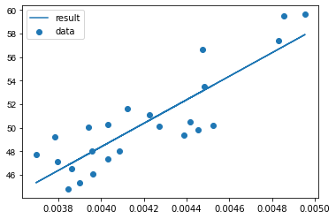

```python
plt.yticks(fontname = "Arial")
plt.scatter(SO2, target, label="data")
plt.plot(SO2, pred1, label="result")
plt.legend()
plt.show()
```

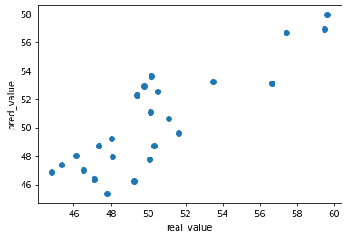

```python
plt.scatter(target,pred1)
plt.xlabel("real_value")
plt.ylabel("pred_value")
plt.show()
```

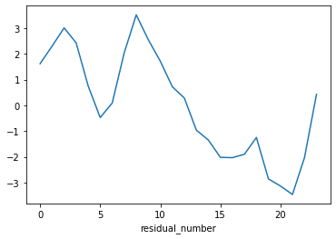

```python
fitted_model1.resid.plot()
plt.xlabel("residual_number")
plt.show()
```

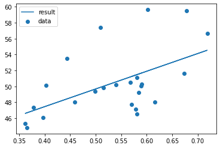

```python
plt.scatter(CO, target, label="data")
plt.plot(CO, pred2, label="result")
plt.legend()
plt.show()
```

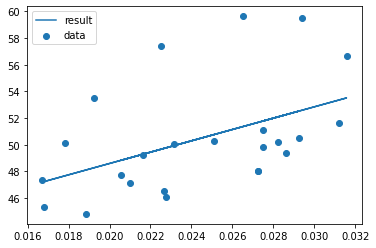

```python
plt.scatter(NO2, target, label="data")
plt.plot(NO2, pred3, label="result")
plt.legend()
plt.show()
```

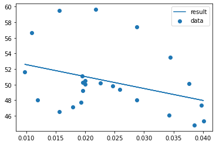

```python
plt.scatter(O3, target, label="data")
plt.plot(O3, pred4, label="result")
plt.legend()
plt.show()
```

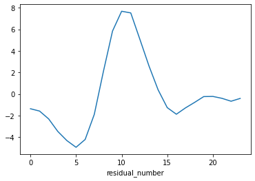

```python
fitted_model2.resid.plot()
plt.xlabel("residual_number")
plt.show()
```

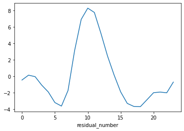

```python
fitted_model3.resid.plot()
plt.xlabel("residual_number")
plt.show()
```

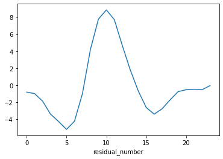

```python
fitted_model4.resid.plot()
plt.xlabel("residual_number")
plt.show()
```

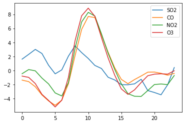

```python
fitted_model1.resid.plot(label='SO2')
fitted_model2.resid.plot(label="CO")
fitted_model3.resid.plot(label="NO2")
fitted_model4.resid.plot(label="O3")
plt.legend()
```

```python
# 잔차의 합 계산
print('SO2 : ', sum(fitted_model1.resid))
print('CO : ', sum(fitted_model2.resid))
print('NO2 : ', sum(fitted_model3.resid))
print('O3 : ', sum(fitted_model4.resid))
```

```
SO2 :  4.689582056016661e-13
CO :  1.3500311979441904e-13
NO2 :  -5.968558980384842e-13
O3 :  -2.8421709430404007e-13
```

잔차의 합이란 `추정한 회귀식이랑 실제 관측 값의 차이`를 말한다.

[figure not shown]

예를 들어, 사진과 같이 4, -2가 있고, 가운데 선이 `회귀선`이고 선에 가까울 수록 좋다는 의미이다. 또한, 잔차로 그래프를 그렸을 때 특정 패턴이 나타나면 회귀직선이 적합하지 않는다는 의미이다.

### target ~ SO2/CO/NO2/O3 (지역)

```python
zipcode_data = data.groupby(['zipcode'], as_index = False).agg({'SO2':'mean', 'NO2':'mean', 'O3':'mean', 'CO':'mean', 'PM10':'mean', 'PM25':'mean'})
```

```python
target = zipcode_data.dropna()[['PM10']]
SO2 = zipcode_data.dropna()[['SO2']]
CO = zipcode_data.dropna()[['CO']]
NO2 = zipcode_data.dropna()[['NO2']]
O3 = zipcode_data.dropna()[['O3']]
```

```python
SO2_2 = sm.add_constant(SO2, has_constant = 'add')
CO_2 = sm.add_constant(CO, has_constant = 'add')
NO2_2 = sm.add_constant(NO2, has_constant = 'add')
O3_2 = sm.add_constant(O3, has_constant = 'add')

model5, model6, model7, model8 = sm.OLS(target, SO2_2), sm.OLS(target,CO_2), sm.OLS(target,NO2_2), sm.OLS(target, O3_2)
fitted_model5, fitted_model6, fitted_model7, fitted_model8 = model5.fit(), model6.fit(), model7.fit(), model8.fit()

fitted_model5.summary()
```

OLS Regression Results

| Dep. Variable: | PM10 | R-squared: | 0.058 |
| --- | --- | --- | --- |
| Model: | OLS | Adj. R-squared: | -0.099 |
| Method: | Least Squares | F-statistic: | 0.3678 |
| Date: | Fri, 18 Jun 2021 | Prob (F-statistic): | 0.566 |
| Time: | 13:03:59 | Log-Likelihood: | -25.159 |
| No. Observations: | 8 | AIC: | 54.32 |
| Df Residuals: | 6 | BIC: | 54.48 |
| Df Model: | 1 |  |  |
| Covariance Type: | nonrobust |  |  |

|  | coef | std err | t | P>\|t\| | [0.025 | 0.975] |
| --- | --- | --- | --- | --- | --- | --- |
| const | 45.2639 | 7.770 | 5.825 | 0.001 | 26.251 | 64.276 |
| SO2 | 1051.0313 | 1733.080 | 0.606 | 0.566 | -3189.664 | 5291.726 |

| Omnibus: | 8.834 | Durbin-Watson: | 2.108 |
| --- | --- | --- | --- |
| Prob(Omnibus): | 0.012 | Jarque-Bera (JB): | 2.948 |
| Skew: | 1.419 | Prob(JB): | 0.229 |
| Kurtosis: | 3.891 | Cond. No. | 756. |

Notes:  
[1] Standard Errors assume that the covariance matrix of the errors is correctly specified.

```python
fitted_model6.summary()
```

OLS Regression Results

| Dep. Variable: | PM10 | R-squared: | 0.002 |
| --- | --- | --- | --- |
| Model: | OLS | Adj. R-squared: | -0.165 |
| Method: | Least Squares | F-statistic: | 0.009428 |
| Date: | Fri, 18 Jun 2021 | Prob (F-statistic): | 0.926 |
| Time: | 13:03:59 | Log-Likelihood: | -25.390 |
| No. Observations: | 8 | AIC: | 54.78 |
| Df Residuals: | 6 | BIC: | 54.94 |
| Df Model: | 1 |  |  |
| Covariance Type: | nonrobust |  |  |

|  | coef | std err | t | P>\|t\| | [0.025 | 0.975] |
| --- | --- | --- | --- | --- | --- | --- |
| const | 51.8096 | 21.178 | 2.446 | 0.050 | -0.011 | 103.630 |
| CO | -3.8496 | 39.646 | -0.097 | 0.926 | -100.860 | 93.161 |

| Omnibus: | 3.705 | Durbin-Watson: | 1.559 |
| --- | --- | --- | --- |
| Prob(Omnibus): | 0.157 | Jarque-Bera (JB): | 1.149 |
| Skew: | 0.926 | Prob(JB): | 0.563 |
| Kurtosis: | 3.122 | Cond. No. | 21.5 |

Notes:  
[1] Standard Errors assume that the covariance matrix of the errors is correctly specified.

```python
fitted_model7.summary()
```

OLS Regression Results

| Dep. Variable: | PM10 | R-squared: | 0.145 |
| --- | --- | --- | --- |
| Model: | OLS | Adj. R-squared: | 0.003 |
| Method: | Least Squares | F-statistic: | 1.018 |
| Date: | Fri, 18 Jun 2021 | Prob (F-statistic): | 0.352 |
| Time: | 13:04:00 | Log-Likelihood: | -24.770 |
| No. Observations: | 8 | AIC: | 53.54 |
| Df Residuals: | 6 | BIC: | 53.70 |
| Df Model: | 1 |  |  |
| Covariance Type: | nonrobust |  |  |

|  | coef | std err | t | P>\|t\| | [0.025 | 0.975] |
| --- | --- | --- | --- | --- | --- | --- |
| const | 34.5728 | 15.214 | 2.272 | 0.063 | -2.655 | 71.801 |
| NO2 | 635.2733 | 629.560 | 1.009 | 0.352 | -905.206 | 2175.752 |

| Omnibus: | 10.786 | Durbin-Watson: | 2.313 |
| --- | --- | --- | --- |
| Prob(Omnibus): | 0.005 | Jarque-Bera (JB): | 3.771 |
| Skew: | 1.584 | Prob(JB): | 0.152 |
| Kurtosis: | 4.127 | Cond. No. | 288. |

Notes:  
[1] Standard Errors assume that the covariance matrix of the errors is correctly specified.

```python
fitted_model8.summary()
```

OLS Regression Results

| Dep. Variable: | PM10 | R-squared: | 0.407 |
| --- | --- | --- | --- |
| Model: | OLS | Adj. R-squared: | 0.308 |
| Method: | Least Squares | F-statistic: | 4.115 |
| Date: | Fri, 18 Jun 2021 | Prob (F-statistic): | 0.0889 |
| Time: | 13:04:00 | Log-Likelihood: | -23.308 |
| No. Observations: | 8 | AIC: | 50.62 |
| Df Residuals: | 6 | BIC: | 50.77 |
| Df Model: | 1 |  |  |
| Covariance Type: | nonrobust |  |  |

|  | coef | std err | t | P>\|t\| | [0.025 | 0.975] |
| --- | --- | --- | --- | --- | --- | --- |
| const | 19.2792 | 15.140 | 1.273 | 0.250 | -17.766 | 56.324 |
| O3 | 1243.5848 | 613.076 | 2.028 | 0.089 | -256.559 | 2743.729 |

| Omnibus: | 0.606 | Durbin-Watson: | 0.787 |
| --- | --- | --- | --- |
| Prob(Omnibus): | 0.738 | Jarque-Bera (JB): | 0.524 |
| Skew: | 0.458 | Prob(JB): | 0.770 |
| Kurtosis: | 2.144 | Cond. No. | 337. |

Notes:  
[1] Standard Errors assume that the covariance matrix of the errors is correctly specified.

### y_hat = beta() + beta * x 계산

```python
# np.dot -> numpy.dot은 numpy array를 곱할 때 사용한다. 두 배열의 내적곱
print('SO2 : ', (np.dot(SO2_2, fitted_model5.params)))
print('CO : ', (np.dot(CO_2, fitted_model6.params)))
print('NO2 : ', (np.dot(NO2_2, fitted_model7.params)))
print('O3 : ', (np.dot(O3_2, fitted_model8.params)))
```

```
SO2 :  [52.10979845 49.27328755 49.74512937 50.63172358 51.38169347 48.05196378
 48.28276128 48.65213487]
CO :  [49.54937909 49.97182674 49.39332046 49.84118476 49.51091611 49.99112815
 50.01722081 49.85351622]
NO2 :  [50.49501112 49.64178657 51.68268317 50.61593129 52.28728405 49.37605711
 44.53659579 49.49314323]
O3 :  [44.81368407 53.99912234 48.43571601 55.95167748 46.55204703 49.06692881
 46.85514917 52.45416742]
```

```python
print(len(np.dot(SO2_2, fitted_model1.params)))
print(len(np.dot(CO_2, fitted_model2.params)))
print(len(np.dot(NO2_2, fitted_model3.params)))
print(len(np.dot(O3_2, fitted_model4.params)))
```

```
8
8
8
8
```

```python
pred5 = fitted_model5.predict(SO2_2)
pred6 = fitted_model6.predict(CO_2)
pred7 = fitted_model7.predict(NO2_2)
pred8 = fitted_model8.predict(O3_2)
```

### 적합시킨 직선 시각화

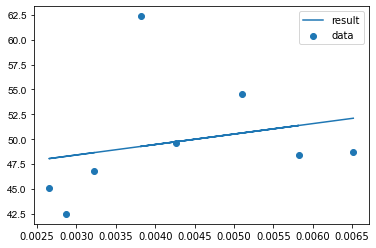

```python
plt.yticks(fontname = "Arial")
plt.scatter(SO2, target, label="data")
plt.plot(SO2, pred5, label="result")
plt.legend()
plt.show()
```

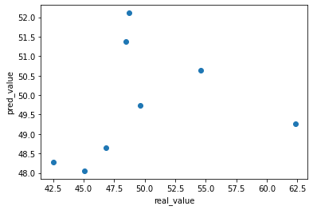

```python
plt.scatter(target,pred5)
plt.xlabel("real_value")
plt.ylabel("pred_value")
plt.show()
```

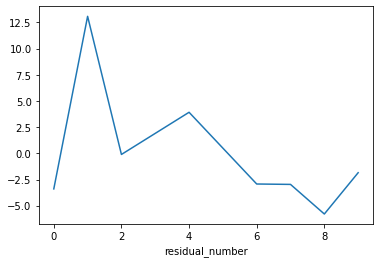

```python
fitted_model5.resid.plot()
plt.xlabel("residual_number")
plt.show()
```

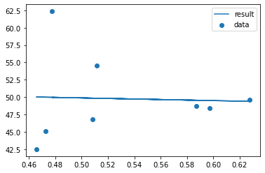

```python
plt.scatter(CO, target, label="data")
plt.plot(CO, pred6, label="result")
plt.legend()
plt.show()
```

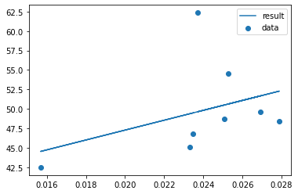

```python
plt.scatter(NO2, target, label="data")
plt.plot(NO2, pred7, label="result")
plt.legend()
plt.show()
```

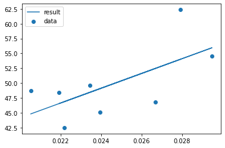

```python
plt.scatter(O3, target, label="data")
plt.plot(O3, pred8, label="result")
plt.legend()
plt.show()
```

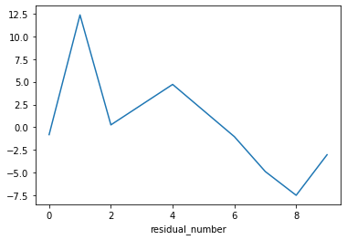

```python
fitted_model6.resid.plot()
plt.xlabel("residual_number")
plt.show()
```

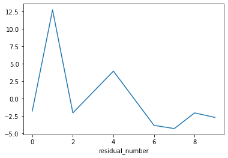

```python
fitted_model7.resid.plot()
plt.xlabel("residual_number")
plt.show()
```

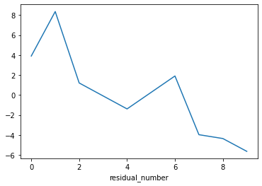

```python
fitted_model8.resid.plot()
plt.xlabel("residual_number")
plt.show()
```

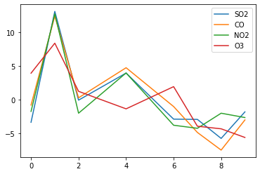

```python
fitted_model5.resid.plot(label='SO2')
fitted_model6.resid.plot(label="CO")
fitted_model7.resid.plot(label="NO2")
fitted_model8.resid.plot(label="O3")
plt.legend()
```

```python
# 잔차의 합 계산
print('SO2 : ', sum(fitted_model5.resid))
print('CO : ', sum(fitted_model6.resid))
print('NO2 : ', sum(fitted_model7.resid))
print('O3 : ', sum(fitted_model8.resid))
```

```
SO2 :  6.394884621840902e-14
CO :  6.536993168992922e-13
NO2 :  -1.4210854715202004e-14
O3 :  -4.121147867408581e-13
```

[figure not shown]

해당 사진(시각화에서 첫 번째 사진)과 같이 적합시킨 직선 시각화에서 직선에 점들이 가깝게 모인 모델들은 괜찮은 모델이다.

## 로지스틱 회귀 분석

```python
# 분석에 필요한 패키지 불러오기
import os
import numpy as np
import pandas as pd
from sklearn.linear_model import LogisticRegression
from sklearn.model_selection import train_test_split
from sklearn import metrics
from sklearn.metrics import confusion_matrix
from sklearn.metrics import accuracy_score, roc_auc_score, roc_curve
import statsmodels.api as sm
import matplotlib.pyplot as plt
import itertools
import time
import copy
```

```python
data = pd.read_csv('Final.csv', engine = 'python', encoding='CP949') # CP949는 한글 깨짐 현상 방지
data = data.dropna(axis = 0)
data = data.dropna().drop(['location', 'zip_location', 'address'], axis = 1, inplace = False)
data = sm.add_constant(data, has_constant = 'add')
data
```

|  | const | zipcode | date | time | SO2 | CO | O3 | NO2 | PM10 | PM25 |
| --- | --- | --- | --- | --- | --- | --- | --- | --- | --- | --- |
| 0 | 1.0 | 525111 | 20170101 | 1 | 0.004 | 1.1 | 0.002 | 0.036 | 40.0 | 34.0 |
| 1 | 1.0 | 525111 | 20170101 | 2 | 0.004 | 1.2 | 0.002 | 0.034 | 40.0 | 38.0 |
| 6 | 1.0 | 525111 | 20170101 | 7 | 0.003 | 1.1 | 0.002 | 0.025 | 40.0 | 34.0 |
| 7 | 1.0 | 525111 | 20170101 | 8 | 0.003 | 1.2 | 0.002 | 0.025 | 38.0 | 32.0 |
| 8 | 1.0 | 525111 | 20170101 | 9 | 0.003 | 0.9 | 0.002 | 0.022 | 37.0 | 32.0 |
| ... | ... | ... | ... | ... | ... | ... | ... | ... | ... | ... |
| 21595 | 1.0 | 525173 | 20170331 | 20 | 0.001 | 0.3 | 0.041 | 0.026 | 28.0 | 25.0 |
| 21596 | 1.0 | 525173 | 20170331 | 21 | 0.001 | 0.3 | 0.037 | 0.021 | 22.0 | 19.0 |
| 21597 | 1.0 | 525173 | 20170331 | 22 | 0.001 | 0.3 | 0.028 | 0.025 | 23.0 | 18.0 |
| 21598 | 1.0 | 525173 | 20170331 | 23 | 0.001 | 0.2 | 0.033 | 0.021 | 21.0 | 14.0 |
| 21599 | 1.0 | 525173 | 20170331 | 24 | 0.001 | 0.2 | 0.037 | 0.016 | 16.0 | 14.0 |

16539 rows × 10 columns

### 변수 분리 및 학습 데이터와 평가 데이터

```python
feature_columns = list(data.columns.difference(['PM10']))
x = data[feature_columns]
# 미세먼지 0 : 정상 1 : 나쁨으로 나누었다.
data.loc[data['PM10'] <=80, '미세먼지'] = 0
data.loc[data['PM10'] > 80, '미세먼지'] = 1
y = data['미세먼지']
print(x)
```

```
        CO    NO2     O3  PM25    SO2  const      date  time  zipcode
0      1.1  0.036  0.002  34.0  0.004    1.0  20170101     1   525111
1      1.2  0.034  0.002  38.0  0.004    1.0  20170101     2   525111
6      1.1  0.025  0.002  34.0  0.003    1.0  20170101     7   525111
7      1.2  0.025  0.002  32.0  0.003    1.0  20170101     8   525111
8      0.9  0.022  0.002  32.0  0.003    1.0  20170101     9   525111
...    ...    ...    ...   ...    ...    ...       ...   ...      ...
21595  0.3  0.026  0.041  25.0  0.001    1.0  20170331    20   525173
21596  0.3  0.021  0.037  19.0  0.001    1.0  20170331    21   525173
21597  0.3  0.025  0.028  18.0  0.001    1.0  20170331    22   525173
21598  0.2  0.021  0.033  14.0  0.001    1.0  20170331    23   525173
21599  0.2  0.016  0.037  14.0  0.001    1.0  20170331    24   525173

[16539 rows x 9 columns]
```

```python
train_x, test_x, train_y, test_y = train_test_split(x, y, stratify = y,train_size = 0.7,test_size = 0.3,random_state = 42)
print(train_x.shape, test_x.shape, train_y.shape, test_y.shape)
```

```
(11577, 9) (4962, 9) (11577,) (4962,)
```

### 로지스틱 회귀모형 모델링 y = f(x)

```python
model = sm.Logit(train_y.astype(float), train_x.astype(float))
result = model.fit(method = 'newton')
```

```python
result.summary()
```

Logit Regression Results

| Dep. Variable: | 미세먼지 | No. Observations: | 11577 |
| --- | --- | --- | --- |
| Model: | Logit | Df Residuals: | 11568 |
| Method: | MLE | Df Model: | 8 |
| Date: | Fri, 18 Jun 2021 | Pseudo R-squ.: | 0.5111 |
| Time: | 13:04:06 | Log-Likelihood: | -1741.8 |
| converged: | False | LL-Null: | -3562.4 |
| Covariance Type: | nonrobust | LLR p-value: | 0.000 |

|  | coef | std err | z | P>\|z\| | [0.025 | 0.975] |
| --- | --- | --- | --- | --- | --- | --- |
| CO | 0.6706 | 0.236 | 2.838 | 0.005 | 0.207 | 1.134 |
| NO2 | 48.2335 | 5.603 | 8.608 | 0.000 | 37.251 | 59.216 |
| O3 | 32.3166 | 3.615 | 8.939 | 0.000 | 25.231 | 39.402 |
| PM25 | 0.1236 | 0.004 | 33.261 | 0.000 | 0.116 | 0.131 |
| SO2 | 54.7749 | 16.829 | 3.255 | 0.001 | 21.790 | 87.759 |
| const | -2.004e+04 | 1.25e+04 | -1.602 | 0.109 | -4.46e+04 | 4483.932 |
| date | 0.0013 | 0.001 | 2.054 | 0.040 | 5.83e-05 | 0.002 |
| time | 0.0119 | 0.007 | 1.589 | 0.112 | -0.003 | 0.027 |
| zipcode | -0.0109 | 0.002 | -5.980 | 0.000 | -0.014 | -0.007 |

```python
print('model AIC : ', '{:.5f}'.format(result.aic))
```

```
model AIC :  3501.58039
```

`AIC`는 데이터셋에 대한 통계 모델의 상대적인 품질 평가 지표이다. 낮을수록 좋다고 하는데 생각보다 높게 나왔다.

```python
result.params
```

```
CO             0.670580
NO2           48.233474
O3            32.316599
PM25           0.123591
SO2           54.774898
const     -20039.406810
date           0.001276
time           0.011898
zipcode       -0.010851
dtype: float64
```

```python
np.exp(result.params)
```

```
CO         1.955371e+00
NO2        8.861998e+20
O3         1.083729e+14
PM25       1.131552e+00
SO2        6.143784e+23
const      0.000000e+00
date       1.001276e+00
time       1.011969e+00
zipcode    9.892077e-01
dtype: float64
```

다음 데이터가 보여주는 것들은 다음과 같다. 예를 하나 들어 설명하겠다.

- np.exp(result.params)
- 입시점수 1.001563
- 학점 0.617389
- dtype: float64

오즈비가 1을 기준으로 큰지 작은지를 파악하여 종속변수에 미치는 영향의 방향을 파악할 수 있다. 독립변수가 두개 이상 있을 때는 다른 독립변수를 일정한 값으로 고정한 경우의 오즈비로 해석된다. 아무런 관계없을 때 오즈비는 1이다. 1에서 멀리 떨어질수록 종속변수와의 관계가 강하다는 뜻이다. 즉, 종속변수 여부에 큰 영향을 준다는 뜻이다. 오즈비는 1을 기준으로 영향을 판단하므로, 오즈비가 10인 경우와 0.1인 경우는 종속변수에 영향을 주는 강도가 같다. 입시점수 변수의 경우, 극도로 1에 가까운 값으로 나타난다. 따라서, 입시점수는 합격여부에 별다른 영향을 주지않았음(관계 없음)을 알 수 있다. 반면, 학점의 경우는 각 오즈비가 0.61로 1과 떨어져있으므로 합격여부에 영향을 미쳤음을 알 수 있다. 독립변수가 수치형일 경우 또 다르게 오즈비해석을 할 수 있다. 학점이 1단위 증가하면 합격할 확률이 0.61배 증가한다는 뜻으로도 해석할 수 있다.

따라서 `CO`가 1이 증가할 때마다, 미세먼지가 나쁨이 될 확률이 1.9배 증가한다는 뜻으로 해석한다. 그리고, 나머지 `O3`, `SO2`, `NO2` 같은 경우는, 값이 매우 낮아서 1이 증가할 때마다 나쁨이 될 확률이 크게 증가한다.

```python
pred_y = result.predict(test_x)
pred_y
```

```
5675     0.088352
20442    0.001676
4114     0.412560
19761    0.000605
17080    0.059894
           ...
8819     0.002550
10554    0.056222
10422    0.018604
13788    0.298409
10364    0.235809
Length: 4962, dtype: float64
```

```python
def cut_off(y, threshold):
    z = copy.deepcopy(y)
    z[z > threshold] = 1
    z[z <= threshold] = 0
    return z.astype(int)

pred_z = cut_off(pred_y, 0.5)
pred_z
```

```
5675     0
20442    0
4114     0
19761    0
17080    0
        ..
8819     0
10554    0
10422    0
13788    0
10364    0
Length: 4962, dtype: int64
```

```python
cfmat = confusion_matrix(test_y, pred_z)
print(cfmat)
```

```
[[4449   55]
 [ 209  249]]
```

```python
(cfmat[0, 0] + cfmat[1, 1]) / np.sum(cfmat) # accuracy
```

```
0.9467956469165659
```

### 임계값 (cut-off)에 따른 성능지표 비교

```python
def acc(cfmat):
    acc = (cfmat[0, 0] + cfmat[1, 1]) / np.sum(cfmat) # accuracy
    return acc

threshold = np.arange(0, 1, 0.1)
table = pd.DataFrame(columns = ['ACC'])

for i in threshold:
    pred_z = cut_off(pred_y, i)
    cfmat = confusion_matrix(test_y, pred_z)
    table.loc[i] = acc(cfmat)

table.index.name = 'threshold'
table.columns.name = 'performance'
table
```

| performance threshold | ACC |
| --- | --- |
| 0.0 | 0.092301 |
| 0.1 | 0.888755 |
| 0.2 | 0.929867 |
| 0.3 | 0.944982 |
| 0.4 | 0.948408 |
| 0.5 | 0.946796 |
| 0.6 | 0.942765 |
| 0.7 | 0.940347 |
| 0.8 | 0.936316 |
| 0.9 | 0.927449 |

```
AUC :  0.923961330830625
```

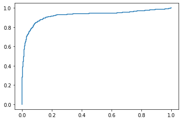

```python
# sklearn ROC 패키지 제공
fpr, tpr, thresholds = metrics.roc_curve(test_y, pred_y, pos_label = 1)

plt.plot(fpr, tpr)

auc = np.trapz(tpr, fpr)
print('AUC : ', auc)
```

## SVM 알고리즘

수업에서 사용한 것으로 해보기

```python
import numpy as np
import pandas as pd
from sklearn.svm import SVC # 사용할 알고리즘
from sklearn.model_selection import train_test_split # 데이터 분할
from sklearn.model_selection import cross_val_score
```

```python
data = pd.read_csv('Final.csv', engine = 'python', encoding='CP949') # CP949는 한글 깨짐 현상 방지
data = data.dropna(axis = 0)
data = data.dropna().drop(['location', 'zip_location', 'address'], axis = 1, inplace = False)
data = sm.add_constant(data, has_constant = 'add')
feature_columns = list(data.columns.difference(['PM10']))
x = data[feature_columns]
# 미세먼지 0 : 정상 1 : 나쁨으로 나누었다.
data.loc[data['PM10'] <=80, '미세먼지'] = 0
data.loc[data['PM10'] > 80, '미세먼지'] = 1
y = data['미세먼지']
```

```python
train_x, test_x, train_y, test_y = train_test_split(data, y, stratify = y,train_size = 0.7,test_size = 0.3,random_state = 42)
print(train_x.shape, test_x.shape, train_y.shape, test_y.shape)
```

```
(11577, 11) (4962, 11) (11577,) (4962,)
```

```python
X_train_d, X_validation, y_train_d, y_validation = train_test_split(train_x,
                                                                train_y,
                                                                test_size = 114,
                                                                stratify = train_y,
                                                                random_state = 321)

print(X_train_d.shape, y_train_d.shape, X_validation.shape, y_validation.shape)
```

```
(11463, 11) (11463,) (114, 11) (114,)
```

```python
np.logspace(-3, 2, num = 6)
```

```
array([1.e-03, 1.e-02, 1.e-01, 1.e+00, 1.e+01, 1.e+02])
```

### 모델구축1

```python
scores = {}
# grid search 6 * 6
for gamma in np.logspace(-3,2,num = 6) :
    for C in np.logspace(-3,2,num = 6) :
        model = SVC(gamma=gamma, C = C)
        model.fit(X_train_d,y_train_d)
        scores[(gamma,C)] = model.score(X_validation, y_validation)

scores = pd.Series(scores)
print(scores.idxmax(), scores.max())
```

```
(0.001, 0.1) 1.0
```

```python
gamma = 0.001
C = 0.1
model = SVC(gamma = gamma, C = C)
```

C는 데이터 샘플들이 다른 클래스에 놓이는 것을 허용하는 정도를 결정하고, gamma는 결정 경계의 곡률을 결정한다.

```python
# 최종 모델 평가, test set 이용
model.fit(train_x, train_y)
model.score(test_x, test_y)
```

```
0.9879081015719468
```

### 모델구축 2

```python
# 모델 구축, Learn Algorithm = SVM, Hyper-parameters = gamma, C
scores = {}
# grid search 6 * 6
for gamma in np.logspace(-3, 2, num = 6) :
    for C in np.logspace(-3, 2, num = 6) :
        model = SVC(gamma = gamma, C = C)
        scores[(gamma, C)] = cross_val_score(model, train_x, train_y, cv=10).mean()

scores = pd.Series(scores)
print(scores.idxmax(), scores.max())
```

```
(0.001, 100.0) 0.9983589415183991
```

```python
# 최종 모델 선택
gamma = 0.001
C = 100.0
model = SVC(gamma = gamma, C = C)

model.fit(train_x, train_y)
model.score(test_x, test_y)
```

```
0.9977831519548569
```

### 모델평가

```python
from sklearn.metrics import confusion_matrix

y_pred = model.predict(test_x)
y_true = test_y
confusion_matrix(y_true, y_pred)
```

```
array([[4500,    4],
       [   7,  451]])
```

```python
tn,fp,fn,tp = confusion_matrix(y_true,y_pred).ravel() # ravel 다차원을 1차원으로 푸는 것
tn,fp,fn,tp
```

```
(4500, 4, 7, 451)
```

```python
#accuracy 1 = 나쁨, 0 = 정상
print('accuracy = ',(tn + tp) / (tn + fp + fn + tp))
#Precision
print('Precision = ',tp / (tp + fp))
#Sensitivity
print('Sensitivity = ',tp / (tp + fn))
#f1 socre
precision = tp / (tp + fp)
sensitivity = tp / (tp + fn)
f1 = 2 / (1 / precision + 1 / sensitivity)
print('f1 score = ',f1)
```

```
accuracy =  0.9977831519548569
Precision =  0.9912087912087912
Sensitivity =  0.9847161572052402
f1 score =  0.9879518072289156
```

```python
# negative = 나쁨, positive = 정상
tp, fn, fp, tn = confusion_matrix(y_true,y_pred).ravel()

#accuracy
print('accuracy = ',(tn + tp) / (tn + fp + fn + tp))
#Precision
print('Precision = ',tp / (tp + fp))
#Sensitivity
print('Sensitivity = ',tp / (tp + fn))
#f1 socre
precision = tp / (tp + fp)
sensitivity = tp / (tp + fn)
f1 = 2 / (1 / precision + 1 / sensitivity)
print('f1 score = ',f1)
```

```
accuracy =  0.9977831519548569
Precision =  0.9984468604393166
Sensitivity =  0.9991119005328597
f1 score =  0.9987792697813783
```

```python
from sklearn.metrics import f1_score
f1_score(y_true,y_pred)
```

```
0.9879518072289157
```

### Cross-validation + Grid Search

- 데이터를 train, validation, test set으로 나누는 방법은 성능이 좋고 널리 사용되지만, 데이터를 나누는 방법에 매우 민감하다.
- 일반화 성능을 더 잘 평가하기 위해서는 훈련 세트와 검증 세트를 한번만 나누지 않고, 교차 검증을 사용해서 각 매개 변수의 조합의 성능을 평가할 수 있다.

```python
data = pd.read_csv('Final.csv', engine = 'python', encoding='CP949') # CP949는 한글 깨짐 현상 방지
data = data.dropna(axis = 0)
data = data.dropna().drop(['location', 'zip_location', 'address'], axis = 1, inplace = False)
data = sm.add_constant(data, has_constant = 'add')
feature_columns = list(data.columns.difference(['PM10']))
x = data[feature_columns]
# 미세먼지 0 : 정상 1 : 나쁨으로 나누었다.
data.loc[data['PM10'] <=80, '미세먼지'] = 0
data.loc[data['PM10'] > 80, '미세먼지'] = 1
y = data['미세먼지']
```

```python
train_x, test_x, train_y, test_y = train_test_split(x, y, test_size = 0.25, random_state = 0)
print(train_x.shape, test_x.shape, train_y.shape, test_y.shape)
```

```
(12404, 9) (4135, 9) (12404,) (4135,)
```

```python
best_score = 0

# Cross-validation + Grid Search
for gamma in [0.001, 0.01, 0.1, 1.0, 10.0, 100.0]:
    for C in [0.001, 0.01, 0.1, 1.0, 10.0, 100.0]:
        # Train SVC using combination of gamma and C
        svm = SVC(gamma = gamma, C = C)
        # evaluate model (svm 모델 사용, 검증을 나누지 않고 train data 사용)
        scores = cross_val_score(svm, train_x, train_y, cv = 5)
        # mean of cross-validation
        score = np.mean(scores)

        # restore the highest score with it's parameter
        if score > best_score:
            best_score = score
            best_parameter = {'gamma' : gamma, 'C' : C}

svm = SVC(**best_parameter)

# train + validation 모두 합한 데이터 가지고 평가
svm.fit(train_x, train_y)
# 테스트에 대한 점수
train_score = svm.score(train_x, train_y)
test_score = svm.score(test_x, test_y)

print(train_score, test_score)
```

```
0.9585617542728152 0.9574365175332528
```

### GridSearchCV

- 교차 검증을 사용한 그리드 서치를 매개변수 조정 방법으로 널리 사용하므로, scikit-learn은 GridSearchCV를 제공하고 있다.
- 검색 대상이 되는 매개변수를 딕셔너리 자료형으로 구성해야 한다.

```python
from sklearn.model_selection import GridSearchCV

# parameter grid 생성
param_grid = {'C' : [0.001, 0.01, 0.1, 1, 10, 100], 'gamma' : [0.001, 0.01, 0.1, 1, 10, 100]}

# GridSearchCV 이용하여 객체 생성
grid_search = GridSearchCV(SVC(), param_grid, cv = 5, return_train_score = True)

train_x, test_x, train_y, test_y = train_test_split(x, y, test_size = 0.2, random_state = 0)

# grid_search model
grid_search.fit(train_x, train_y)

# model evaluation
print('test set score : {}'.format(grid_search.score(test_x, test_y)))

# best parameter and best score
print('best parameters : {}'.format(grid_search.best_params_))
print('best score {}'.format(grid_search.best_score_))
```

```
test set score : 0.9567714631197098
best parameters : {'C': 100, 'gamma': 0.001}
best score 0.9538960948103373
```

### 교차 검증 결과 분석

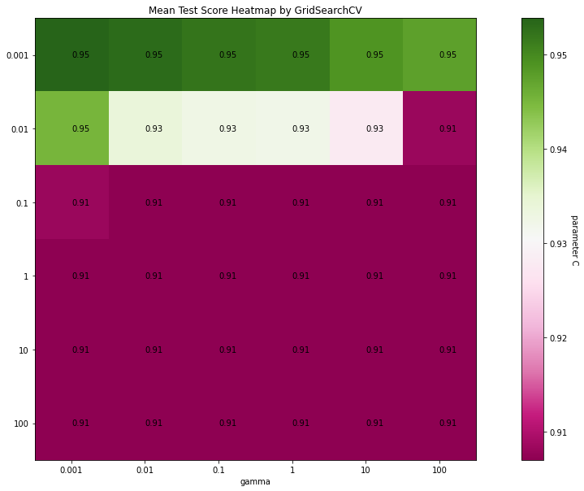

```python
results = pd.DataFrame(grid_search.cv_results_)

results.head(5)

scores = np.array(results.mean_test_score.sort_values(ascending = False)).reshape(6, 6)
fig, ax = plt.subplots(figsize = (20, 10))
im = ax.imshow(scores, cmap = 'PiYG')
cbar = ax.figure.colorbar(im, ax = ax)
cbar.ax.set_ylabel(ylabel = 'parameter C', rotation = -90, va = 'bottom')
ax.set_xticks(np.arange(len(set(results.param_gamma))))
ax.set_yticks(np.arange(len(set(results.param_C))))

ax.set_xticklabels(param_grid['gamma'])
ax.set_yticklabels(param_grid['C'])

for i in range(len(param_grid['C'])):
    for j in range(len(param_grid['gamma'])):
        text = ax.text(j, i, np.round(scores[i, j], 2), va = 'center', color = 'k')

ax.set_title('Mean Test Score Heatmap by GridSearchCV')
ax.set_xlabel('gamma')
```

- 결과를 시각화하면 검색 대상 매개변수가 모델의 일반화에 영향을 주는 정도를 이해하는데 도움을 준다.
- grid search는 연산 비용이 높으므로, 비교적 간격을 넓게 하여 적은 수의 그리드로 시작하는 것이 좋다.
- 이후 결과를 분석하여 검색을 확장해 나갈 수 있다.
- 그리드 서치의 결과는 cv*results* 속성에 있다.

## 고찰

데이터 분석을 아주 짧게 공부하고 그만두었었다. 그래서인지 예전에 했던 것들인데도 너무 어렵게 느껴졌다. 서버 사이드 개발자로 희망 진로를 바꾸게 되면서 데이터 분석을 아예 공부하지 않았지만, 아주 짧게나마 다시 복기할 수 있는 수업이었다.

우선, 학원을 다니고, 취업 준비를 병행하느라 수업에 집중을 많이 못했던 것 같다. 특히 중간고사 이전보다 중간고사 이후가 많이 바빴다. 외주를 하면서 18학점이라는 수업을 듣고 있기에 모든 수업을 따라가기가 힘들었다. 그래서 외주가 6월 초에 끝났는데, 그 기간부터 공부를 다시 시작했다. 빅데이터 뿐만 아니라 다른 수업도 해야 됐고, 다른 수업들은 시험을 봐야했기에 빅데이터 과제를 수행하기에는 시간이 조금 많이 모잘라 저번 데이터 분석 과제 점수가 많이 낮았던 것 같다. 그래서 이번 과제에 조금 시간을 많이 들였고, 최대한 많은 알고리즘을 사용하려 했다.

처음, 분석을 하기 전 강의를 처음부터 다 봤다. 하지만 강의를 보면서 느낀 것은 데이터 분석을 할 수 있을까란 생각이 많이 들었다. 그래서 구글링이나 유튜브를 통해 강의를 들었고, 코드를 조금씩 익히기 시작했다. 그리고 용어들의 의미들도 많이 찾아보면서 공부를 했다. 과제 시작은 상관 계수부터 시작했다.

상관 계수는 미세먼지 데이터를 분석하기에 좋을 것 같아서 넣었다. 히트맵을 이용하여, 한눈에 미세먼지와 관련 있는 것들을 보기 쉽게 만들었다. 하지만 조금 아쉬운 점이 있다면, 지역과 시간 별로 데이터를 분석하는 것이 조금 아쉬웠다. 행이 비교적 작아졌기 때문이다.

로지스틱 회귀 방법과, 단순 회귀는 인터넷에서 많이 찾아보고 유튜브에서 강의를 들었다. 처음 시간을 많이 쓴 것은 단순 회귀에서 많이 썼다. 분석에 쓰이는 용어들을 알아보고, 라이브러리 등 알아보느라 조금 시간을 많이 썼고, 로지스틱 같은 경우는 미세먼지 범위를 어떻게 설정하면 좋을지에 대해서 고민을 했다. 원래는 좋음/나쁨/매우나쁨 세개로 나뉘지만 좋음과 나쁨으로 두개로 나누어 사용했다.

SVM 알고리즘 같은 경우는 수업시간에 알려준 방식을 먼저 사용해봤다. 하지만 결과 값이 조금 이상한 것 같아 C와 gamma를 직접 찾는 방식을 찾아보았고, 그것이 cross-validation Grid Search이다. SVM 알고리즘은 연산 수행이 굉장히 오래걸렸다. 하나가 실행 되는데 짧으면 10분, 길면 30분까지 걸렸다. 그래서 초기에 오타 체크라던가 조금 꼼꼼히 했었다.

학기 초 18학점 중 빅데이터만 자신이 있었고, 나머지 과목들은 자신이 없었다. 하지만 학기가 끝나갈 무렵 빅데이터의 성적이 너무 걱정 되었고, 나머지 수업들은 결과가 좋게 나왔다,, 중간고사 때도 공부한 것에 비해 비교적 아쉬운 결과를 받았다. 그래서 기말고사 대체 과제에 시간을 많이 썼다.

교수님과 짧은 인연이 생겨서 좋았습니다. 그리고, 첫 수업에도 불구하고 수업을 이끌어가시는 형태는 좋았습니다. 저는 이제 졸업을 하게 돼서 이제 학교에 없지만, 앞으로 더 나은 강의를 위해 노력해주시면 감사하겠습니다.